```python
import pickle
%matplotlib inline
import numpy as np
import matplotlib
import matplotlib.pyplot as plt
import scipy
from scipy import stats
import pandas as pd
```

```python
infile1 = open ("higgs_100000_pt_1000_1200.pkl",'rb')
dictH = pickle.load(infile1)
infile2 = open ("qcd_100000_pt_1000_1200.pkl",'rb')
dictQ = pickle.load(infile2)
```

# LAB 7

# Problem 1

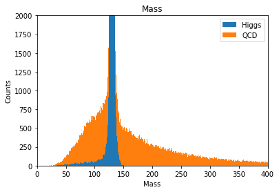

```python
plt.title('Mass')
plt.xlabel('Mass')
plt.ylabel('Counts')
plt.hist([dictH['mass'],dictQ['mass']],bins=800,density=False,alpha=1,label=['Higgs','QCD'],stacked=True);
#plt.hist(dictH['mass'],bins=800,density=False,alpha=.5,label='Higgs',stacked=True);
plt.ylim(0,2000);
plt.legend()
plt.xlim(0,400);
```

Set the signal as 50 and background as 2000

```python
n_higgs = 50
n_qcd = 2000
```

```python
sig_p = stats.poisson.cdf(2050,mu=2000)
exp_sig = stats.norm.ppf(sig_p)
print("The significance without any even selection is"+str(exp_sig))
calc_sig = (n_higgs)/np.sqrt(n_qcd)
print("'NHiggs/(√NQCD) is'"+str(calc_sig))
print('Difference between them is '+str(exp_sig-calc_sig))
```

```
The significance without any even selection is1.1282230087754428
'NHiggs/(√NQCD) is'1.118033988749895
Difference between them is 0.01018902002554789
```

Not equivalent

# Problem 2

```python
sig_p = stats.poisson.cdf(2050,mu=2000)
exp_sig = stats.norm.ppf(sig_p)
print(exp_sig)
```

```
1.1282230087754428
```

```python
sigsleft = np.zeros(40)
for i in range(1,41):
    maskH = ((90+i)<dictH['mass'])&(dictH['mass']<150)
    CUTH = dictH['mass'][maskH]
    maskQ = ((90+i)<dictQ['mass'])&(dictQ['mass']<150)
    CUTQ = dictQ['mass'][maskQ]
    nhiggs = (len(CUTH)/100000) * n_higgs
    nqcd = (len(CUTQ)/100000) * n_qcd
    sig_perc = stats.poisson.cdf(nqcd+nhiggs,mu=nqcd)
    sigsleft[i-1] = stats.norm.ppf(sig_perc)
print(sigsleft[33])
print('34+90 gives highest significance from the left (124)')
```

```
2.6188118919874657
34+90 gives highest significance from the left (124)
```

```python
sigsright = np.zeros(40)
for i in range(1,41):
    maskH = ((124)<dictH['mass'])&(dictH['mass']<150-i)
    CUTH = dictH['mass'][maskH]
    maskQ = ((124)<dictQ['mass'])&(dictQ['mass']<150-i)
    CUTQ = dictQ['mass'][maskQ]
    nhiggs = (len(CUTH)/100000) * n_higgs
    nqcd = (len(CUTQ)/100000) * n_qcd
    sig_perc = stats.poisson.cdf(nqcd+nhiggs,mu=nqcd)
    sigsright[i-1] = stats.norm.ppf(sig_perc)
print(sigsright[20])
print("150-21 gives highest sig overall (129)")
```

```
4.004006485304592
150-21 gives highest sig overall (129)
```

From this we can conclude that the optimized range is between 124 and 129

```python
maskOH = (124<dictH['mass'])&(dictH['mass']<129)
CUTmassH = dictH['mass'][maskOH]

maskOQ = (124<dictQ['mass'])&(dictQ['mass']<129)
CUTmassQ = dictQ['mass'][maskOQ]
numhig1 = (len(CUTmassH)/100000)*50
numqcd1 = (len(CUTmassQ)/100000)*2000
oct = stats.norm.ppf(stats.poisson.cdf(numhig1+numqcd1,mu=numqcd1))
print(" optimized cut values is "+str(oct))
```

```
 optimized cut values is 4.004006485304592
```

# Problem 3

All the graph on the left represent the uncut data and right represent the optimal mass cut

pT

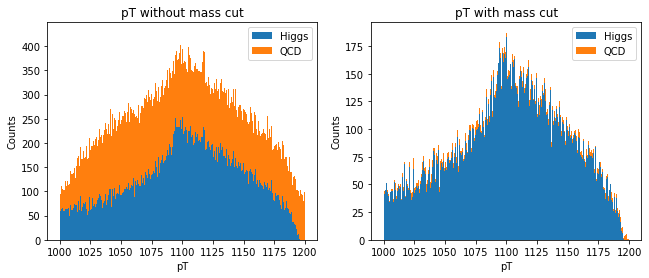

```python
plt.subplots(1,2)
plt.subplots_adjust(right=1.5)
plt.subplot(1,2,1)
plt.title('pT without mass cut')
plt.ylabel('Counts')
plt.xlabel('pT')
plt.hist([dictH['pt'],dictQ['pt']],bins=800,density=False,alpha=1,label=['Higgs','QCD'],stacked=True);
plt.legend();
plt.subplot(1,2,2)
plt.title('pT with mass cut')
plt.hist([dictH['pt'][maskOH],dictQ['pt'][maskOQ]],bins=800,density=False,alpha=1,label=['Higgs','QCD'],stacked=True);
plt.ylabel('Counts')
plt.xlabel('pT')
plt.legend();
```

Eta

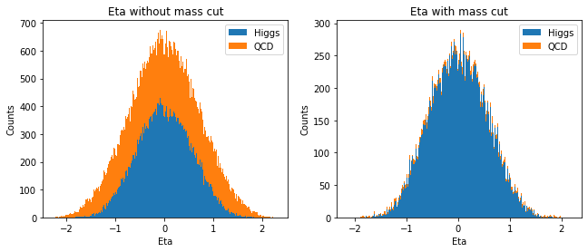

```python
plt.subplots(1,2)
plt.subplots_adjust(right=1.5)
plt.subplot(1,2,1)
plt.title('Eta without mass cut')
plt.ylabel('Counts')
plt.xlabel('Eta')
plt.hist([dictH['eta'],dictQ['eta']],bins=800,density=False,alpha=1,label=['Higgs','QCD'],stacked=True);
plt.legend();
plt.subplot(1,2,2)
plt.title('Eta with mass cut')
plt.hist([dictH['eta'][maskOH],dictQ['eta'][maskOQ]],bins=800,density=False,alpha=1,label=['Higgs','QCD'],stacked=True);
plt.ylabel('Counts')
plt.xlabel('Eta')
plt.legend();
```

Phi

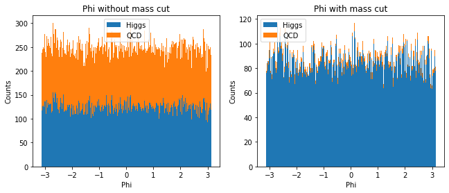

```python
plt.subplots(1,2)
plt.subplots_adjust(right=1.5)
plt.subplot(1,2,1)
plt.title('Phi without mass cut')
plt.ylabel('Counts')
plt.xlabel('Phi')
plt.hist([dictH['phi'],dictQ['phi']],bins=800,density=False,alpha=1,label=['Higgs','QCD'],stacked=True);
plt.legend();
plt.subplot(1,2,2)
plt.title('Phi with mass cut')
plt.hist([dictH['phi'][maskOH],dictQ['phi'][maskOQ]],bins=800,density=False,alpha=1,label=['Higgs','QCD'],stacked=True);
plt.ylabel('Counts')
plt.xlabel('Phi')
plt.legend();
```

mass

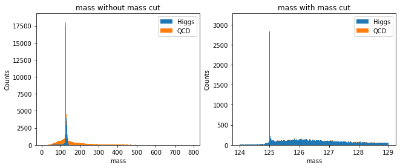

```python
plt.subplots(1,2)
plt.subplots_adjust(right=1.5)
plt.subplot(1,2,1)
plt.title('mass without mass cut')
plt.ylabel('Counts')
plt.xlabel('mass')
plt.hist([dictH['mass'],dictQ['mass']],bins=800,density=False,alpha=1,label=['Higgs','QCD'],stacked=True);
plt.legend();
plt.subplot(1,2,2)
plt.title('mass with mass cut')
plt.hist([dictH['mass'][maskOH],dictQ['mass'][maskOQ]],bins=800,density=False,alpha=1,label=['Higgs','QCD'],stacked=True);
plt.ylabel('Counts')
plt.xlabel('mass')
plt.legend();
```

ee2

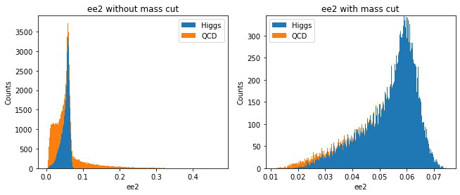

```python
plt.subplots(1,2)
plt.subplots_adjust(right=1.5)
plt.subplot(1,2,1)
plt.title('ee2 without mass cut')
plt.ylabel('Counts')
plt.xlabel('ee2')
plt.hist([dictH['ee2'],dictQ['ee2']],bins=800,density=False,alpha=1,label=['Higgs','QCD'],stacked=True);
plt.legend();
plt.subplot(1,2,2)
plt.title('ee2 with mass cut')
plt.hist([dictH['ee2'][maskOH],dictQ['ee2'][maskOQ]],bins=800,density=False,alpha=1,label=['Higgs','QCD'],stacked=True);
plt.ylabel('Counts')
plt.xlabel('ee2')
plt.legend();
```

ee3

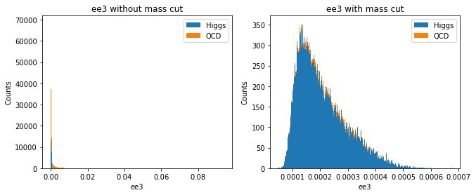

```python
plt.subplots(1,2)
plt.subplots_adjust(right=1.5)
plt.subplot(1,2,1)
plt.title('ee3 without mass cut')
plt.ylabel('Counts')
plt.xlabel('ee3')
plt.hist([dictH['ee3'],dictQ['ee3']],bins=800,density=False,alpha=1,label=['Higgs','QCD'],stacked=True);
plt.legend();
plt.subplot(1,2,2)
plt.title('ee3 with mass cut')
plt.hist([dictH['ee3'][maskOH],dictQ['ee3'][maskOQ]],bins=800,density=False,alpha=1,label=['Higgs','QCD'],stacked=True);
plt.ylabel('Counts')
plt.xlabel('ee3')
plt.legend();
```

d2

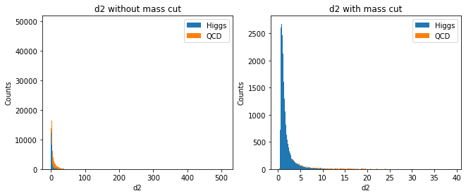

```python
plt.subplots(1,2)
plt.subplots_adjust(right=1.5)
plt.subplot(1,2,1)
plt.title('d2 without mass cut')
plt.ylabel('Counts')
plt.xlabel('d2')
plt.hist([dictH['d2'],dictQ['d2']],bins=800,density=False,alpha=1,label=['Higgs','QCD'],stacked=True);
plt.legend();
plt.subplot(1,2,2)
plt.title('d2 with mass cut')
plt.hist([dictH['d2'][maskOH],dictQ['d2'][maskOQ]],bins=800,density=False,alpha=1,label=['Higgs','QCD'],stacked=True);
plt.ylabel('Counts')
plt.xlabel('d2')
plt.legend();
```

Angularity

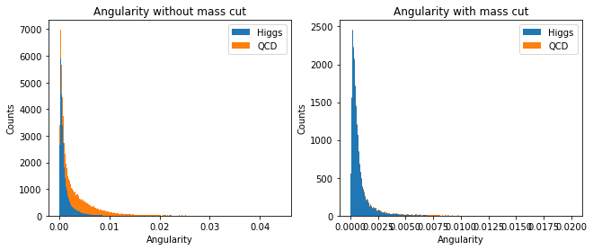

```python
plt.subplots(1,2)
plt.subplots_adjust(right=1.5)
plt.subplot(1,2,1)
plt.title('Angularity without mass cut')
plt.ylabel('Counts')
plt.xlabel('Angularity')
plt.hist([dictH['angularity'],dictQ['angularity']],bins=800,density=False,alpha=1,label=['Higgs','QCD'],stacked=True);
plt.legend();
plt.subplot(1,2,2)
plt.title('Angularity with mass cut')
plt.hist([dictH['angularity'][maskOH],dictQ['angularity'][maskOQ]],bins=800,density=False,alpha=1,label=['Higgs','QCD'],stacked=True);
plt.ylabel('Counts')
plt.xlabel('Angularity')
plt.legend();
```

t1

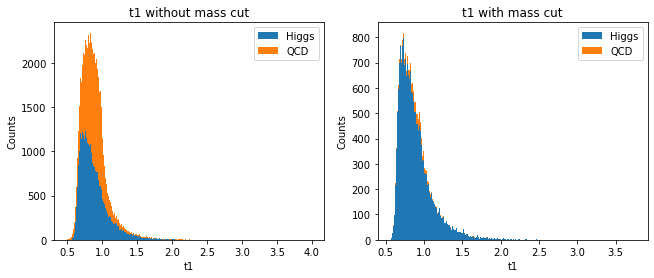

```python
plt.subplots(1,2)
plt.subplots_adjust(right=1.5)
plt.subplot(1,2,1)
plt.title('t1 without mass cut')
plt.ylabel('Counts')
plt.xlabel('t1')
plt.hist([dictH['t1'],dictQ['t1']],bins=800,density=False,alpha=1,label=['Higgs','QCD'],stacked=True);
plt.legend();
plt.subplot(1,2,2)
plt.title('t1 with mass cut')
plt.hist([dictH['t1'][maskOH],dictQ['t1'][maskOQ]],bins=800,density=False,alpha=1,label=['Higgs','QCD'],stacked=True);
plt.ylabel('Counts')
plt.xlabel('t1')
plt.legend();
```

t2

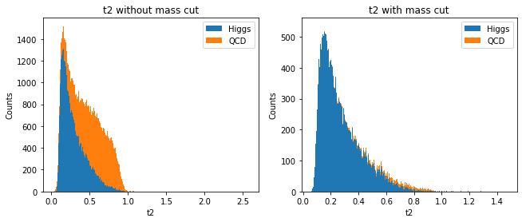

```python
plt.subplots(1,2)
plt.subplots_adjust(right=1.5)
plt.subplot(1,2,1)
plt.title('t2 without mass cut')
plt.ylabel('Counts')
plt.xlabel('t2')
plt.hist([dictH['t2'],dictQ['t2']],bins=800,density=False,alpha=1,label=['Higgs','QCD'],stacked=True);
plt.legend();
plt.subplot(1,2,2)
plt.title('t2 with mass cut')
plt.hist([dictH['t2'][maskOH],dictQ['t2'][maskOQ]],bins=800,density=False,alpha=1,label=['Higgs','QCD'],stacked=True);
plt.ylabel('Counts')
plt.xlabel('t2')
plt.legend();
```

t3

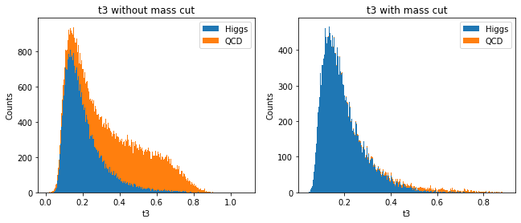

```python
plt.subplots(1,2)
plt.subplots_adjust(right=1.5)
plt.subplot(1,2,1)
plt.title('t3 without mass cut')
plt.ylabel('Counts')
plt.xlabel('t3')
plt.hist([dictH['t3'],dictQ['t3']],bins=800,density=False,alpha=1,label=['Higgs','QCD'],stacked=True);
plt.legend();
plt.subplot(1,2,2)
plt.title('t3 with mass cut')
plt.hist([dictH['t3'][maskOH],dictQ['t3'][maskOQ]],bins=800,density=False,alpha=1,label=['Higgs','QCD'],stacked=True);
plt.ylabel('Counts')
plt.xlabel('t3')
plt.legend();
```

t21

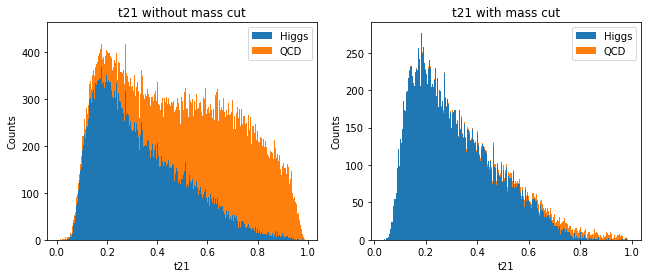

```python
plt.subplots(1,2)
plt.subplots_adjust(right=1.5)
plt.subplot(1,2,1)
plt.title('t21 without mass cut')
plt.ylabel('Counts')
plt.xlabel('t21')
plt.hist([dictH['t21'],dictQ['t21']],bins=800,density=False,alpha=1,label=['Higgs','QCD'],stacked=True);
plt.legend();
plt.subplot(1,2,2)
plt.title('t21 with mass cut')
plt.hist([dictH['t21'][maskOH],dictQ['t21'][maskOQ]],bins=800,density=False,alpha=1,label=['Higgs','QCD'],stacked=True);
plt.ylabel('Counts')
plt.xlabel('t21')
plt.legend();
```

t32

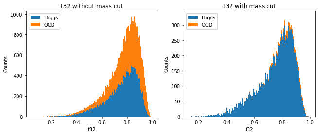

```python
plt.subplots(1,2)
plt.subplots_adjust(right=1.5)
plt.subplot(1,2,1)
plt.title('t32 without mass cut')
plt.ylabel('Counts')
plt.xlabel('t32')
plt.hist([dictH['t32'],dictQ['t32']],bins=800,density=False,alpha=1,label=['Higgs','QCD'],stacked=True);
plt.legend();
plt.subplot(1,2,2)
plt.title('t32 with mass cut')
plt.hist([dictH['t32'][maskOH],dictQ['t32'][maskOQ]],bins=800,density=False,alpha=1,label=['Higgs','QCD'],stacked=True);
plt.ylabel('Counts')
plt.xlabel('t32')
plt.legend();
```

KtDeltaR

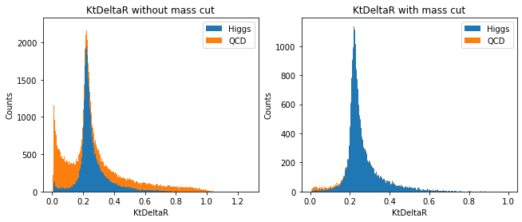

```python
plt.subplots(1,2)
plt.subplots_adjust(right=1.5)
plt.subplot(1,2,1)
plt.title('KtDeltaR without mass cut')
plt.ylabel('Counts')
plt.xlabel('KtDeltaR')
plt.hist([dictH['KtDeltaR'],dictQ['KtDeltaR']],bins=800,density=False,alpha=1,label=['Higgs','QCD'],stacked=True);
plt.legend();
plt.subplot(1,2,2)
plt.title('KtDeltaR with mass cut')
plt.hist([dictH['KtDeltaR'][maskOH],dictQ['KtDeltaR'][maskOQ]],bins=800,density=False,alpha=1,label=['Higgs','QCD'],stacked=True);
plt.ylabel('Counts')
plt.xlabel('KtDeltaR')
plt.legend();
```

Problem 4

To improve the performance, I will choose d2 for further classification

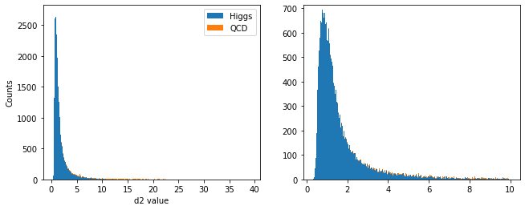

```python
plt.subplots(1,2)
plt.subplots_adjust(right=1.5)
plt.subplot(1,2,1)
plt.hist([dictH['d2'][maskOH],dictQ['d2'][maskOQ]],bins=800,density=False,alpha=1,label=['Higgs','QCD'],stacked=True);
plt.ylabel('Counts')
plt.xlabel('d2 value')
plt.legend();

plt.subplot(1,2,2)
masked_x = dictH['d2'][maskOH]
masked_y = dictQ['d2'][maskOQ]
ocut_H = ((0<dictH['d2'][maskOH])&(dictH['d2'][maskOH]<10))
ocut_Q = ((0<dictQ['d2'][maskOQ])&(dictQ['d2'][maskOQ]<10))
plt.hist([masked_x[ocut_H],masked_y[ocut_Q]],bins=800,density=False,alpha=1,label=['Higgs','QCD'],stacked=True);
```

```python
n_hig = (len(masked_x[ocut_H])/100000)*50
n_qcd = (len(masked_y[ocut_Q])/100000)*2000
stats.norm.ppf(stats.poisson.cdf(n_hig+n_qcd,mu=n_qcd))
```

```
5.005161955195693
```

We achieved a improvement of 1.001 sigma by additionally cutting the d2 data

# Bonus

[figure not shown]

```python
plt.figure(figsize=(25,10))
plt.subplot(1,2,1)
plt.hist2d(maskQ, dictQ['d2'])
plt.title('Histogram of Mass and d2 for QCD Data',fontsize=25)
plt.subplot(1,2,2)
plt.title(' Histogram of Mass and d2 for Higgs Data',fontsize=25)
plt.hist2d(maskH, dictH['d2'])
plt.show()
```

We can see the Higgs data has a better sensitivity

# LAB8

```python
import h5py
hl = h5py.File('data_highLumi_pt_1000_1200.h5', 'r')
dataHL = hl.get('data').get('block0_values')
ll = h5py.File('data_lowLumi_pt_1000_1200.h5', 'r')
dataLL = ll.get('data').get('block0_values')
hl['data']['block0_items'][:]
```

```
array([b'pt', b'eta', b'phi', b'mass', b'ee2', b'ee3', b'd2',
       b'angularity', b't1', b't2', b't3', b't21', b't32', b'KtDeltaR'],
      dtype='|S10')
```

# Problem 1 High Luminosity

Do the same step as lab7(drawing historgram of mass and d2)

1.Mass

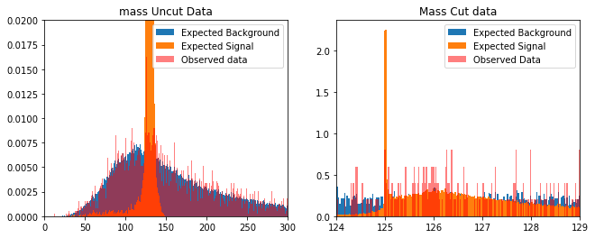

```python
plt.subplots(1,2)
plt.subplots_adjust(right=1.5)
plt.subplot(1,2,1)

plt.title('mass Uncut Data')
plt.hist(dictQ['mass'],bins=800,density=True,label='Expected Background')
plt.hist(dictH['mass'],bins=800,density=True,label='Expected Signal')
plt.hist(dataHL[:,3],bins=800,density=True,alpha=.5,color='red',label='Observed data');
plt.xlim(0,300)
plt.ylim(0,.02)

plt.legend()
plt.subplot(1,2,2)
plt.title('Mass Cut data')
obscut = ((124<dataHL[:,3])&(dataHL[:,3]<129))
plt.hist(dictQ['mass'][maskOQ],bins=200,density=True,label='Expected Background')
plt.hist(dictH['mass'][maskOH],bins=200,density=True,label='Expected Signal')
plt.hist(dataHL[:,3][obscut],bins=200,density=True,alpha=.5,color='red',label='Observed Data');
plt.xlim(124,129)
plt.legend()
```

Calculate the Expected Significance and Observed Significance

```python
new_obsN = 50*(len(dataHL[:,3]))/len(dictH['mass'])
new_obsQ = 2000*(len(dataHL[:,3]))/len(dictQ['mass'])


print('Expected Significance: '+str(stats.norm.ppf(stats.poisson.cdf(numhig1+numqcd1,mu=numqcd1))))
cut_obsN = (len(dataHL[:,3][obscut]))/len(dataHL[:,3])
print('Observed Significance: '+str(stats.norm.ppf(stats.poisson.cdf((new_obsN*cut_obsN)+(new_obsQ*cut_obsN),mu=(new_obsQ*cut_obsN)))))
```

```
Expected Significance: 4.004006485304592
Observed Significance: 0.3287745118692216
```

2.d2

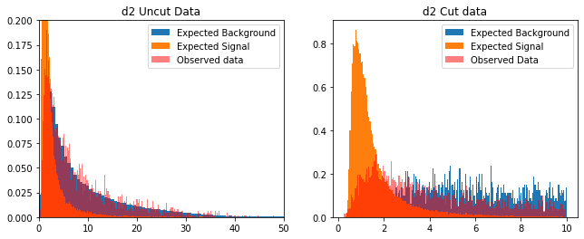

```python
plt.subplots(1,2)
plt.subplots_adjust(right=1.5)
plt.subplot(1,2,1)
plt.title('d2 Uncut Data')
plt.hist(dictQ['d2'],bins=800,density=True,label='Expected Background')
plt.hist(dictH['d2'],bins=800,density=True,label='Expected Signal')
plt.hist(dataHL[:,6],bins=800,density=True,alpha=.5,color='red',label='Observed data');
plt.xlim(0,50)
plt.ylim(0,.2)
plt.legend()
plt.subplot(1,2,2)
plt.title('d2 Cut data')
obscut = ((0<dataHL[:,6])&(dataHL[:,6]<10))
plt.hist(masked_y[ocut_Q],bins=200,density=True,label='Expected Background')
plt.hist(masked_x[ocut_H],bins=200,density=True,label='Expected Signal')
plt.hist(dataHL[:,6][obscut],bins=200,density=True,alpha=.5,color='red',label='Observed Data');
plt.legend();
```

Calculate the Expected Significance and Observed Significance

```python
new_obsN = 50*(len(dataHL[:,6]))/len(dictH['d2'])
new_obsQ = 2000*(len(dataHL[:,6]))/len(dictQ['d2'])


print('Expected Significance: '+str(stats.norm.ppf(stats.poisson.cdf(n_hig+n_qcd,mu=n_qcd))))
cut_obsN = (len(dataHL[:,6][obscut]))/len(dataHL[:,6])
print('Observed Significance: '+str(stats.norm.ppf(stats.poisson.cdf((new_obsN*cut_obsN)+(new_obsQ*cut_obsN),mu=(new_obsQ*cut_obsN)))))
```

```
Expected Significance: 5.005161955195693
Observed Significance: 0.25806489391138887
```

# Problem 2 Low Luminosity

1.Mass

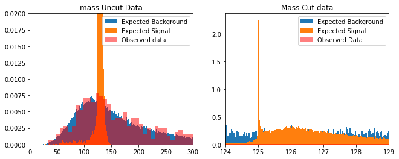

```python
plt.subplots(1,2)
plt.subplots_adjust(right=1.5)
plt.subplot(1,2,1)
plt.title('mass Uncut Data')
plt.hist(dictQ['mass'],bins=800,density=True,label='Expected Background')
plt.hist(dictH['mass'],bins=800,density=True,label='Expected Signal')
plt.hist(dataLL[:,3],bins=80,density=True,alpha=.5,color='red',label='Observed data');
plt.xlim(0,300)
plt.ylim(0,.02)
plt.legend()
plt.subplot(1,2,2)
plt.title('Mass Cut data')
obscut = ((0<dataLL[:,6])&(dataLL[:,6]<10))
plt.hist(dictQ['mass'][maskOQ],bins=200,density=True,label='Expected Background')
plt.hist(dictH['mass'][maskOH],bins=200,density=True,label='Expected Signal')
plt.hist(dataLL[:,3][obscut],bins=20,density=True,alpha=.5,color='red',label='Observed Data');
plt.xlim(124,129)
plt.legend();
```

Calculate the Expected Significance and Observed Significance

```python
new_obsN = 50*(len(dataLL[:,3]))/len(dictH['mass'])
new_obsQ = 2000*(len(dataLL[:,3]))/len(dictQ['mass'])
print('Expected Significance: '+str(stats.norm.ppf(stats.poisson.cdf(numhig1+numqcd1,mu=numqcd1))))
cut_obsN = (len(dataLL[:,3][obscut]))/len(dataLL[:,3])
print('Observed Significance: '+str(stats.norm.ppf(stats.poisson.cdf((new_obsN*cut_obsN)+(new_obsQ*cut_obsN),mu=(new_obsQ*cut_obsN)))))
```

```
Expected Significance: 4.004006485304592
Observed Significance: 0.1708105114103634
```

2.D2

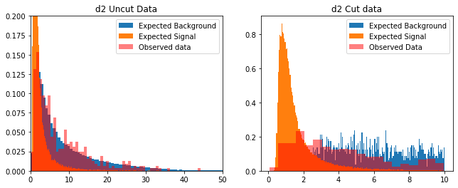

```python
plt.subplots(1,2)
plt.subplots_adjust(right=1.5)
plt.subplot(1,2,1)
plt.title('d2 Uncut Data')
plt.hist(dictQ['d2'],bins=800,density=True,label='Expected Background')
plt.hist(dictH['d2'],bins=800,density=True,label='Expected Signal')
plt.hist(dataLL[:,6],bins=80,density=True,alpha=.5,color='red',label='Observed data');
plt.xlim(0,50)
plt.ylim(0,.2)
plt.legend()

plt.subplot(1,2,2)
plt.title('d2 Cut data')
plt.hist(masked_y[ocut_Q],bins=200,density=True,label='Expected Background')
plt.hist(masked_x[ocut_H],bins=200,density=True,label='Expected Signal')
plt.hist(dataLL[:,6][obscut],bins=20,density=True,alpha=.5,color='red',label='Observed Data');
plt.legend();
```

Calculate the Expected Significance and Observed Significance

```python
new_obsN = 50*(len(dataLL[:,6]))/len(dictH['mass'])
new_obsQ = 2000*(len(dataLL[:,6]))/len(dictQ['mass'])
print('Expected Significance: '+str(stats.norm.ppf(stats.poisson.cdf(n_hig+n_qcd,mu=n_qcd))))
cut_obsN = (len(dataLL[:,6][obscut]))/len(dataLL[:,6])
print('Observed Significance: '+str(stats.norm.ppf(stats.poisson.cdf((new_obsN*cut_obsN)+(new_obsQ*cut_obsN),mu=(new_obsQ*cut_obsN)))))
```

```
Expected Significance: 5.005161955195693
Observed Significance: 0.1708105114103634
```

# Problem 3

```python
obs_conf = stats.poisson.ppf(q=.95,mu=.1708105)
print('Observed confidence interval upper limit: '+str(obs_conf))
exp_conf = stats.poisson.ppf(q=.95,mu=5.005)
print('Expected confidence interval upper limit: '+str(exp_conf))
```

```
Observed confidence interval upper limit: 1.0
Expected confidence interval upper limit: 9.0
```

The expected upper limit is larger than the observed limit. This could be due to the amount of data given in the expected data pool compared to the smaller amount from the observed data. More data means better accuracy in measurements.